# Unevaluated expressions

Updated on Thursday, January 09, 2025 03:11 PM

TJ Mahr

- January 2025
  - Use GAMs for assessing nonlinearity of effects
  - `sweep()` demo
  - Log-likelihood functions
  - Bits and pieces
- January 2024
  - Links
  - One-off knitr engine for blockquoting things
  - Simulation for a probability paradox
  - Sentence similarity
  - How I got targets to handle a bunch of bootstrapping
  - targets + crew
  - MFA note: don’t touch the solver
  - Revelation while reading withr 3.0.0 release
  - A silly function
  - The pipe placeholder works better now
  - `purrr::pluck()` is better than I had realized
  - Mutual recursion demo
  - Speaking of tail calls, how to write an “iterative” recursive function
- May 2023
  - Gompertz functions
- December 2022
  - duckdb
- September 2022
  - The BIC
- June 2022
  - Getting downlit to work on this notebook
  - Windows Terminal settings for Miniconda
- April, May 2022
  - .Rprofile contents
  - R 4.2.0 alpha notes
- February 2022
  - Phonotactic probability
  - R code to parse the KU phonotactic probability calculator output
  - Some old random walk code
- January 2022
  - Manually delete a facet cell
  - Compute spline predictions manually from GAMLSS
  - Count number of function calls in some R code
- December 2021
  - Quick hits
- November 2021
  - Quick hits
  - `eval()` is stack inconsistent (whatever that means)
  - The Gaussian KDE is a sum of baby Gaussians?!
  - Using closures to make 16 related functions
- OneNote archive
  - Standardized gamma distributions (2019-04-18)
  - Jaccard similarity (2019-03-14)
  - Phylogenetic regression (2019-02-26)
  - multicomp (2019-02-25)
  - Rolling list of bookmarks (2019-10-01)
- Colophon
- References

Notes to self and other noodlings. [Main site](https://tjmahr.com/).

## January 2025

Source: `2025-01-08.Rmd`

Another year, another shot at taking notes.

### Use GAMs for assessing nonlinearity of effects

A [Data Colada post](https://datacolada.org/121) describes a problem and one proposed solution: how to assess a moderator’s interaction in a model like `y ~ x + z + x:z`. One paper suggests binning the covariate into thirds and fitting separate regressions on the bins. Uri Simonsohn observes that this approach is biased when the `y ~ x` or `y ~ z` relationship is nonlinear.

> The third problem is that if x and z in that x·z interaction are correlated, and either x or z impacts y non-linearly, the estimate of interaction term, d, in y=a+bx+cz+dxz is biased, and the binning estimator from the Political Analysis paper is also biased, possibly by the same amount.

> Most notably, one is likely to find false-positive interactions, and marginal effects of the wrong sign.

The author instead advocates for using a “GAM simple slope” and point to [their article (DOI: 10.1177/2515245923120778)](https://urisohn.com/sohn_files/papers/interacting.pdf).

The thing that I like most about the article from skimming it is that it describes curves that are linear and ceiling out as “canopy” shaped.

### `sweep()` demo

`sweep(data, margin, stats, fun)` is a goofy function for adjusting cols or rows. For example, you can subtract the mean and divide by the SD to get *z*-scores:

```r
d <- mtcars
d_scale <- d |> lapply(scale) |> as.data.frame()
d_sweep <- d |>
  sweep(2, colMeans(d), `-`) |>
  sweep(2, apply(d, 2, sd), `/`)
all(d_scale$mpg == d_sweep$mpg)
```

```
#> [1] TRUE
```

### Log-likelihood functions

These two ways of computing the log-likelihood (an automatic way and naive way) differ because `sigma(m)` estimates sigma so it applies a (1 / (N - p)) correction but `logLik()` does not.

```r
m <- lm(mpg ~ wt + disp, mtcars)
logLik(m)
```

```
#> 'log Lik.' -78.08389 (df=4)
```

```r
ls <- dnorm(mtcars$mpg, predict(m), sigma(m))
sum(log(ls))
```

```
#> [1] -78.15893
```

### Bits and pieces

- a [good distribution](https://besjournals.onlinelibrary.wiley.com/doi/full/10.1111/2041-210X.14387) for count data (DOI: 10.1111/2041-210X.14387)
- use `parallelly::availableCores()` instead of `parallel::detectCores()` because of [problems with the latter](https://www.jottr.org/2022/12/05/avoid-detectcores/)
  - [flint R package](https://github.com/etiennebacher/flint) for fast code linting and fixing lints. I like how the author tested the package by linting and repairing huge R packages (e.g., ggplot2 or targets) and getting the patches accepted.

**Default for an NA value**. A trick in the linked post on `parallel::detectCores()` to replace a possible `NA` with a safe default: `max(default, possible_na, na.rm = TRUE)`.

**Random variables**. [“A random variable is not random and not a variable”](https://youtu.be/KQHfOZHNZ3k). Yep, it’s a random number generator or a function. Lol, just for fun, let’s make a random variable into an actual random variable (a code variable that emits a random value every time it is evaluated):

```r
makeActiveBinding("die_value", function(x) sample(1:6, 1), .GlobalEnv)
die_value
```

```
#> [1] 2
```

```r
c(die_value, die_value, die_value, die_value)
```

```
#> [1] 2 4 1 3
```

```r
mean(replicate(1000, die_value))
```

```
#> [1] 3.465
```

```r
mean(1:6)
```

```
#> [1] 3.5
```

## January 2024

Source: `2024-01-19.Rmd`

### Links

- https://0.30000000000000004.com/ - I can never remember how to search for this URL.

### One-off knitr engine for blockquoting things

Here’s how easy it is to create a knitr language engine:

```r
# create a custom language block that blockquotes its contents
knitr::knit_engines$set("blockquote" = function(options) {
  if (isFALSE(options$echo)) return()

  output <- paste0("> ", options$code, collapse = "\n")

  if (!is.null(options$source_url)) {
    output <- sprintf("%s\n[[source]](%s)", output, options$source_url)
  }

  output
})
```

Writing a chunk like:

````
```{blockquote}
#| source_url: https://tjmahr.com
Look at this **markdown**!

Here is a nested blockquote:

  > Cool!

Yes.
```
````

Will yield the following output:

> Look at this **markdown**!

> Here is a nested blockquote:

> > Cool!

> Yes. [[source]](https://tjmahr.com)

I wanted to make this a hook function but couldn’t figure it out.

### Simulation for a probability paradox

This paradox is a flavor of the [Sleeping Beauty](https://en.wikipedia.org/wiki/Sleeping_Beauty_problem) paradox or the [Boy or Girl](https://en.wikipedia.org/wiki/Boy_or_girl_paradox) paradox.

> You are given an urn containing 100 balls; n of them are red, and 100-n are green, where n is chosen uniformly at random in [0, 100]. You take a random ball out of the urn—it’s red—and discard it. The next ball you pick (out of the 99 remaining) is: [poll omitted] [[source]](https://twitter.com/littmath/status/1751648838501224790)

And here is some code I wrote to run a simulation to get the unexpected solution.

```r
f <- function(n = 100) {
  n_red <- sample.int(n, 1)
  p1 <- n_red / n
  p2 <- (n_red - 1) / (n - 1)
  draw <- sample(c("r", "g"), 1, prob = c(p1, 1 - p1))
  if (draw == "g") {
    "skip"
  } else {
    sample(c("r", "g"), 1, prob = c(p2, 1 - p2))
  }
}
counts <- replicate(100000, f()) |>
  table()
counts
```

```
#>
#>     g     r  skip
#> 16837 33846 49317
```

```r
# p(color | first red)
counts[1:2] |> proportions()
```

```
#>
#>         g         r
#> 0.3322021 0.6677979
```

### Sentence similarity

I read an [article](https://txt.cohere.com/what-is-similarity-between-sentences/) I had bookmarked for a while. Suppose you have word embedding (vector) for each word. Or suppose you have a sentence embedding.

> The Cohere embedding assigns a vector of length 4096 (i.e., a list of 4096 numbers) to each sentence. Furthermore, the multilingual embedding does this for sentences in more than 100 languages. In this way, the sentence “Hello, how are you?” and its corresponding French translation, “Bonjour, comment ça va?” will be assigned very similar numbers, as they have the same semantic meaning. [[article](https://txt.cohere.com/what-is-similarity-between-sentences/)]

They have toy data about where some movies are assigned vectors:

```r
df_movies <- data.frame(
  row.names = c("you've got mail", "rush hour", "rush hour 2", "taken"),
  action = c(0, 6, 7, 7),
  comedy = c(5, 5, 4, 0)
)
movies <- df_movies|> as.matrix()
movies
```

```
#>                 action comedy
#> you've got mail      0      5
#> rush hour            6      5
#> rush hour 2          7      4
#> taken                7      0
```

One option for similarity is the dot product of the vectors. (Why?)

```r
# the two rush hour movies
sum(movies[2, ] * movies[3, ])
```

```
#> [1] 62
```

```r
# all at once
dot_products <- movies %*% t(movies)
```

Check this out. `as.dist()` will clean up the redundant output, but it discards the diagonal. [Suggestion from StackOverflow](https://stackoverflow.com/questions/2535234/find-cosine-similarity-between-two-arrays).

```r
as.dist(dot_products)
```

```
#>             you've got mail rush hour rush hour 2
#> rush hour                25
#> rush hour 2              20        62
#> taken                     0        42          49
```

Another option is cosine similarity. They plot the points on a coordinate space and observe:

> […] we want a measure of similarity that is high for sentences that are close to each other, and low for sentences that are far away from each other. [Euclidean] Distance does the exact opposite. So in order to tweak this metric, let’s look at the angle between the rays from the origin (the point with coordinates [0,0]), and each sentence. Notice that this angle is small if the points are close to each other, and large if the points are far away from each other. Now we need the help of another function, the cosine. The cosine of angles close to zero is close to 1 […] [[article](https://txt.cohere.com/what-is-similarity-between-sentences/)]

According to [Wikipedia](https://en.wikipedia.org/wiki/Cosine_similarity), we can derive the cosine similarity from the dot-product:

$$\begin{aligned}
\mathbf{A}\cdot\mathbf{B}&=\left\|\mathbf{A}\right\|\left\|\mathbf{B}\right\|\cos\theta
\\
{\mathbf{A} \cdot \mathbf{B} \over \|\mathbf{A}\| \|\mathbf{B}\|} &=
\cos(\theta) \\
\|\mathbf{m}\| &:= \sqrt{\mathbf{m} \cdot \mathbf{m}}
~~~~~\text{(Euclidean norm)}
\end{aligned}$$

We have a matrix with all of the dot products ready to go, so we need a matrix of all norms multiplied together.

```r
dot_products
```

```
#>                 you've got mail rush hour rush hour 2 taken
#> you've got mail              25        25          20     0
#> rush hour                    25        61          62    42
#> rush hour 2                  20        62          65    49
#> taken                         0        42          49    49
```

```r
norms <- sqrt(rowSums(movies ^ 2))
norm_products <- norms %*% t(norms)

(dot_products / norm_products) |> as.dist() |> round(3)
```

```
#>             you've got mail rush hour rush hour 2
#> rush hour             0.640
#> rush hour 2           0.496     0.985
#> taken                 0.000     0.768       0.868
```

This value is cosine similarity. If we use 1 - similarity, it’s cosine distance. That would be more appropriate for anything piped into `as.dist()`.

Still, two points could be very different distances from the origin, but they could have an angle of 0.

### How I got targets to handle a bunch of bootstrapping

Here is a summary:

- transient memory
- not letting errors on one branch stop the whole pipeline
- `tarchetypes::tar_group_by()`
- `format = "fst_tbl"` or `format = "qs"`
- `tar_read(..., 1)`

My bootstraps would instantly fill up my computer’s memory during a build. So now I dump stuff out of memory with `"transient"`. (You can do this on a by-target level too.) I also keep running the build if one target/branch fails:

```r
tar_option_set(
  error = "null",
  memory = "transient"
)
```

I also split a single target into smaller ones. I declare a global partition value like

```r
N_PARTITIONS <- 80
```

Then I used `tarchetypes::tar_group_by()` to tell targets to split a giant dataframe into groups that can be dynamically branched over. Here is some actual code in the `_targets.R` file. The first targets defines 2000 bootstrap replicates to be split into 80 partitions/branches and the second fits the models on each partition/branch.

```r
  tar_group_by(
    straps,
    data_iwpm |>
      filter(!is.na(mean_wpm)) |>
      prepare_bootstrap_data() |>
      bootstrap_by_slpg(
        times = n_boot,
        col_child_id = subject_id,
        seed = 20220621
      ) |>
      mutate(partition = assign_partition_numbers(id, N_PARTITIONS)),
    partition
  ),
  tar_target(
    models_intelligibility,
    fit_bootstrap_models(straps, "mean_intel", "intelligibility", 3, 2),
    pattern = map(straps),
    format = "qs"
  ),
# btw the targets here themselves are built serially bc fit_bootstrap_models()
# and friends use furrr to fit the models in each branch in parallel
```

But to be honest, as I’m looking at this code, I’m realizing that this “making a giant thing and split into branches” have been built as “make a small table of branch IDs and grow them within each branch”. Analogy would be to read in a dozen files at once and split up the work so each file is processed separately versus take a dozen filenames and handle from each filename separately.

I have to use `tarchetypes::tar_group_by()` instead of `tarchetypes::tar_group_count()` because I have multiple datasets that I am bootstrapping and they need to be kept together within a branch. Like, to split the following into two branches, I would want `bootstrap_number` 1 and 2 in one branch and 3 in a separate branch so that I can compare `a`, `b` and `c` within each bootstrap.

```
data_set,bootstrap_number
a,1
b,1
c,1
a,2
b,2
c,2
a,3
b,3
c,3
```

For serializing the data, I used `format = "qs"` on models or lists of models and `format = "fst_tbl"` on plain, inoffensive data tables.

I also started using `targets::tar_read(blah, n)` where `n` is some selection of branches like `1` or `c(1, 2, 4)`, to read a subset of the overall data. This speeds up interactive development by giving me a smaller subset of data to write code around without having to load gigantic objects into R.

### targets + crew

In targets, by default, targets are dispatched to be built one at a time, but we can use crew so that multiple workers can build targets in parallel. Here is the code to add to `_targets.R` to get 2 workers.

```r
targets::tar_option_set(
  controller = crew::crew_controller_local(workers = 2)
)
```

And then you can view how much work each worker did. (I’m hard-coding the returns to show what happened with a full sit build.)

```r
targets::tar_crew()
```

```
#>   controller               worker seconds targets
#>   <chr>                     <int>   <dbl>   <int>
#> 1 8f28e966dd6adaf60895eb01      1    49.4      32
#> 2 8f28e966dd6adaf60895eb01      2    25.1       9
```

### MFA note: don’t touch the solver

My colleague and I independently ran into an issue where the Montreal Forced Aligner installation with conda seemed to take forever during the solving environment stage. We both tried to fix this problem by changing the default solver. This change did lead to improved installation, but the MFA could not run at all. The correct thing to do is **do nothing**. Just use the default solver and wait it out.

### Revelation while reading withr 3.0.0 release

I was reading the [withr 3.0.0 release notes](https://www.tidyverse.org/blog/2024/01/withr-3-0-0/) and noticed a pleasing symmetry the `with_` and `local_` functions.

The `local_` functions set a temporary value within some local scope, like a `local()` or a `function()`.

```r
local({
  withr::local_language("fr")
  plot[[1]]
})
```

```
#> Error in plot[[1]]: objet de type 'closure' non indiçable
```

```r
plot[[1]]
```

```
#> Error in plot[[1]]: object of type 'closure' is not subsettable
```

The `with_` functions set a temporary value around some block of code.

```r
withr::with_language("fr", {
  plot[[1]]
})
```

```
#> Error in plot[[1]]: objet de type 'closure' non indiçable
```

```r
plot[[1]]
```

```
#> Error in plot[[1]]: object of type 'closure' is not subsettable
```

So where are we working from?

- `local_`: within the code (scope)
- `with_`: around the code

Oh, and the notes for withr 3.0.0, indicates that I should keep an eye on how `source()` interacts with withr.

### A silly function

I got sick of writing null-guard clauses like:

```r
my_cool_function <- function(data, ...) {
  if (is.null(data)) {
    return(NULL)
  }

  #  rest of the function
  nrow(data)
}
```

So why can’t I just make that a higher order function:

```r
nullsafe_map <- function(x, f, ...) {
  if (is.null(x)) NULL else f(x, ...)
}

mtcars |>
  nullsafe_map(my_cool_function) |>
  nullsafe_map(log)
```

```
#> [1] 3.465736
```

```r
NULL |>
  nullsafe_map(my_cool_function) |>
  nullsafe_map(log)
```

It feels like I reinvented something vaguely monad-y here, and [I posted the question](https://staging.bsky.app/profile/tjmahr.com/post/3kiq3hhlvis2m): “What have I reinvented here?” Tan suggested “`purrr::map_if()` with `.p = Negate(is.null)`?” which is cool because I had forgotten about `purrr::map_if()`.

### The pipe placeholder works better now

[Andrew Heiss pointed out to me](https://staging.bsky.app/profile/andrew.heiss.phd/post/3ki4b46li6l2y) that the placeholder since 4.3.0 is a lot better.

```r
quote(
  model |> _$coef |> _[1]
)
```

```
#> model$coef[1]
```

Previously, I had been circumventing these functions with things like `getElement()` or making my own pipe-friendly wrapper functions like:

```r
vec_element <- function(xs, i) {
  xs[[i]]
}

vec_index <- function(xs, i) {
  xs[i]
}

vec_index_into <- function(i, xs) {
  xs[i]
}

vec_replace_na <- function(xs, replacement) {
  xs[is.na(xs)] <- replacement
  xs
}

vec_remove_na <- function(xs) {
  xs[!is.na(xs)]
}

vec_set_names <- function(xs, ns) {
  names(xs) <- ns
  xs
}
```

There were two other functions alongside these helpers that weren’t meant to solve any specific piping problem. I came to adore them when I was doing some Advent of Code puzzles for fun in base R.

```r
vec_which_value <- function(xs, value, negate = FALSE) {
  (xs %in% value) |>
    xor(negate) |>
    which()
}

vec_which_name <- function(xs, name, negate = FALSE) {
  vec_which_value(names(xs), name, negate)
}

letters |>
  vec_which_value(c("a", "e", "i", "o", "u"), negate = TRUE) |>
  vec_index_into(letters)
```

```
#>  [1] "b" "c" "d" "f" "g" "h" "j" "k" "l" "m" "n" "p" "q" "r" "s" "t" "v" "w" "x"
#> [20] "y" "z"
```

### `purrr::pluck()` is better than I had realized

From `?purrr::pluck()`:

> [`pluck()`] also accepts arbitrary accessor functions, i.e. functions that take an object and return some internal piece. […] Compare: `accessor(x[[1]])$foo` to `pluck(x, 1, accessor, "foo")`.

### Mutual recursion demo

I toyed with the experimental `Tailcall` feature in R-devel. I can’t actually run this code when rendering the notebook, but the basic idea is that `sys.nframe()` shows the height of the stack when the recursion bottoms out and it is much smaller in tha `Tailcall` examples.

```r
is_even <- function(n) {
  if (n == 0) list(TRUE, sys.nframe()) else Tailcall(is_odd, n - 1)
}
is_odd <- function(n) {
  if (n == 0) list(FALSE, sys.nframe()) else Tailcall(is_even, n - 1)
}
is_odd(30)

naive_is_even <- function(n) {
  if (n == 0) list(TRUE, sys.nframe()) else naive_is_odd(n - 1)
}
naive_is_odd <- function(n) {
  if (n == 0) list(FALSE, sys.nframe()) else naive_is_even(n - 1)
}
naive_is_odd(30)
```

### Speaking of tail calls, how to write an “iterative” recursive function

I revisited *SICP* during the Christmas break. I don’t know why this stuck out to me this time—it’s a chapter 1 topic, I have definitely seen it—but SICP differentiates between two kinds of recursive functions. Here is the example in R with factorial. First, let’s make sure that multiplication grows the stack by making it a function call instead of whatever kind of primitive `*` is.

```r
`%times%` <- function(a, b) a * b

fact1 <- function(n) {
  if (n == 0) {
    message("nframe of fact1: ", sys.nframe())
    1
  } else {
    n %times% fact1(n - 1)
  }
}

fact2 <- function(n) {
  fact_iter <- function(n, accumulator) {
    if (n == 0) {
      message("nframe of fact2: ", sys.nframe())
      1 %times% accumulator
    } else {
      accumulator <- n %times% accumulator
      n <- n - 1
      fact_iter(n, accumulator)
    }
  }
  fact_iter(n, 1)
}

message("nframe of this code block: ", sys.nframe())
```

```
#> nframe of this code block: 41
```

```r
fact1(10)
```

```
#> nframe of fact1: 62
#> [1] 3628800
```

```r
fact2(10)
```

```
#> nframe of fact2: 53
#> [1] 3628800
```

The difference is that `n %times% fact(n - 1)` in `fact()` grows into a giant single multiplication but `fact_iter(n - 1, n %times% accumulator)` in `fact2()` does not.

The *SICP* authors [describe the difference](https://sarabander.github.io/sicp/html/1_002e2.xhtml#g_t1_002e2_002e1) between the two like so:

> Consider the first process. […] The expansion occurs as the process builds up a chain of *deferred operations* (in this case, a chain of multiplications). […] This type of process, characterized by a chain of deferred operations, is called a *recursive process*. Carrying out this process requires that the interpreter keep track of the operations to be performed later on. In the computation of $n!$, the length of the chain of deferred multiplications, and hence the amount of information needed to keep track of it, grows linearly with $n$ (is proportional to $n$), just like the number of steps. […]

> [In the second process, at] each step, all we need to keep track of, for any $n$, are the current values of the variables [`n` and `accumulator` in my code]. We call this *an iterative process*. In general, an iterative process is one whose state can be summarized by a fixed number of *state variables*, together with a fixed rule that describes how the state variables should be updated as the process moves from state to state and an (optional) end test that specifies conditions under which the process should terminate.

With something like Fibonacci, where two recursively defined things are added together, means that the number of deferred additions grows exponentially.

## May 2023

Source: `2023-05-04.Rmd`

### Gompertz functions

The [Gompertz function](https://en.wikipedia.org/wiki/Gompertz_function) “describes growth as being slowest at the start and end of a given time period. The right-side or future value asymptote of the function is approached much more gradually by the curve than the left-side or lower valued asymptote.”

$$f(t) = a\mathrm{e}^{-b\mathrm{e}^{-ct}} \\
a: \textrm{asymptote} \\
b: \textrm{translation left or right} \\
c: \textrm{growth factor} \\$$

So we have two different growth rates but a single parameter relating to growth rate. R’s implementation (`stats::SSgompertz()`) “simplifies” the double exponential into `Asym * exp(-b2 * b3 ^ x)`.

The scaling factor c or b3 makes sense in the original Gompertz equation. I couldn’t understand what the R version was doing because it was changing the base of exponentiation.

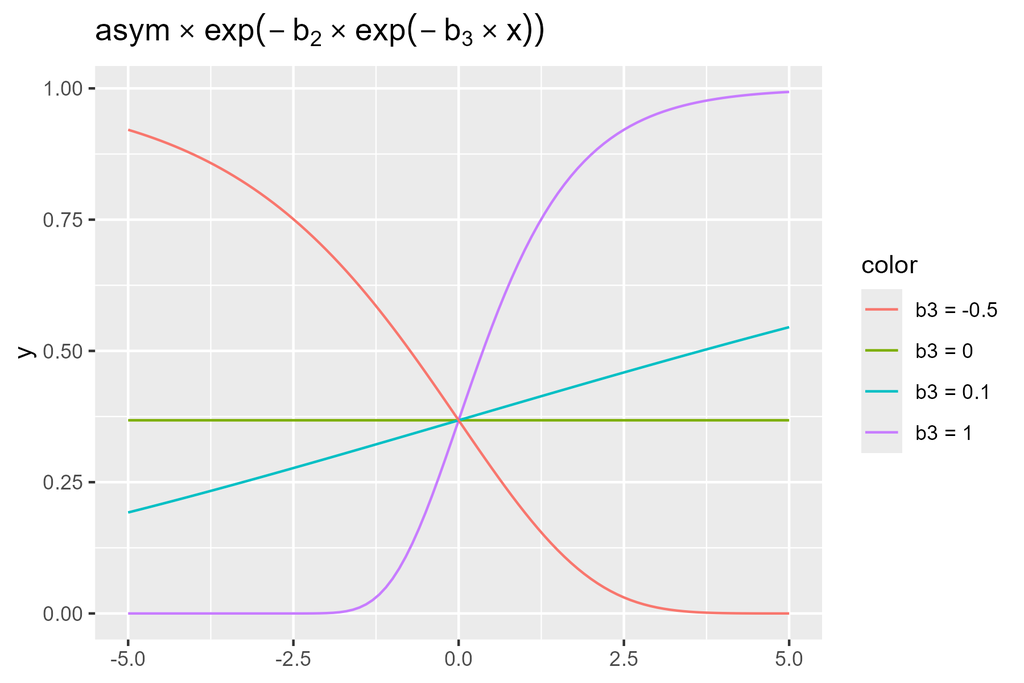

```r
library(tidyverse)

gompertz <- function(xs, asym, b2, b3) {
  asym * exp(-b2 * exp(-b3 * xs))
}

# Make a quick ggplot2 layer of the gompertz function
stat_gompertz <- function(focus, asym, b2, b3, ...) {
  # show what i typed, not the values
  b2 <- rlang::enexpr(b2)
  asym <- rlang::enexpr(asym)
  b3 <- rlang::enexpr(b3)
  labs <- list(
    asym = rlang::expr_deparse(asym),
    b2 = rlang::expr_deparse(b2),
    b3 = rlang::expr_deparse(b3)
  )
  rlang::dots_list(asym, b2, b3, .named = TRUE)
  color <- sprintf("%s = %s", focus, labs[[focus]])
  stat_function(
    aes(color = color),
    fun = gompertz,
    args = rlang::inject(list(asym = !! asym, b2 = !! b2, b3 = !! b3)),
    ...
  )
}

ggplot() +
  xlim(-5, 5) +
  stat_gompertz("b3", 1, 1, 1) +
  stat_gompertz("b3", 1, 1, 0) +
  stat_gompertz("b3", 1, 1, .1) +
  stat_gompertz("b3", 1, 1, -.5) +
  ggtitle(
      expression(asym %*% exp(-b[2] %*% exp(-b[3] %*% x)))
  )
```

We have this weird feature where $b = 1/2$ and $b = 2$ are the same distance from $b = 1$, and the distance between the $b = 2, 3, 4$ gets smaller.

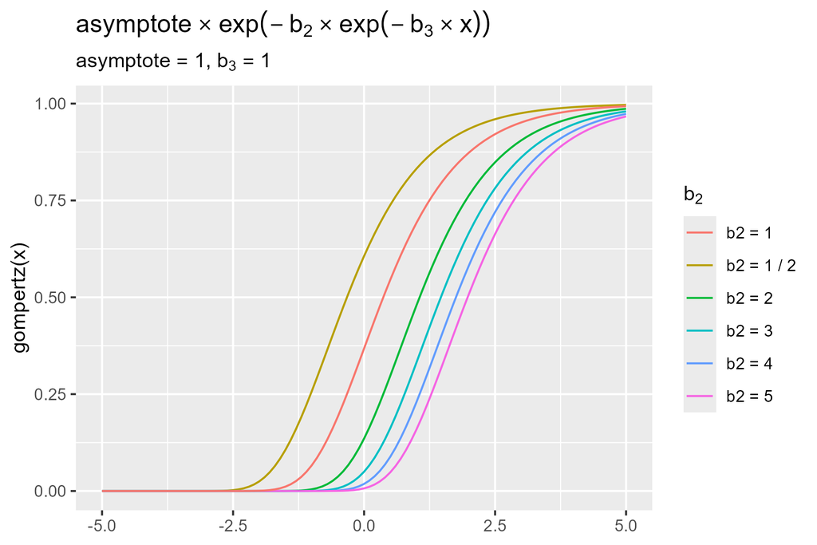

```r
ggplot() +
  xlim(-5, 5) +
  stat_gompertz("b2", 1, 1/2, 1) +
  stat_gompertz("b2", 1, 2, 1) +
  stat_gompertz("b2", 1, 3, 1) +
  stat_gompertz("b2", 1, 4, 1) +
  stat_gompertz("b2", 1, 5, 1) +
  stat_gompertz("b2", 1, 1, 1) +
  ggtitle(
    expression(asymptote %*% exp(-b[2] %*% exp(-b[3] %*% x)))
  ) +
  labs(
    y = "gompertz(x)",
    color = expression(b[2]),
    subtitle = expression(paste(asymptote == 1, ", ", b[3] == 1))
  )
```

But the horizontal spacing of the lines is more regular when I pass in `exp()` expressions.

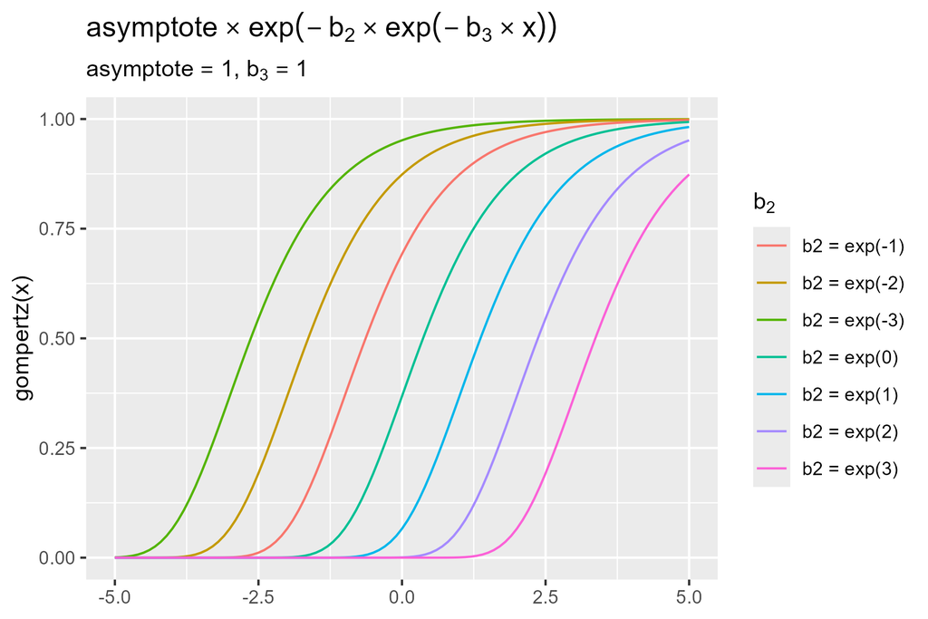

```r
ggplot() +
  xlim(-5, 5) +
  stat_gompertz("b2", 1, exp(-3), 1) +
  stat_gompertz("b2", 1, exp(-2), 1) +
  stat_gompertz("b2", 1, exp(-1), 1) +
  stat_gompertz("b2", 1, exp(0), 1) +
  stat_gompertz("b2", 1, exp(1), 1) +
  stat_gompertz("b2", 1, exp(2), 1) +
  stat_gompertz("b2", 1, exp(3), 1) +
  ggtitle(
    expression(asymptote %*% exp(-b[2] %*% exp(-b[3] %*% x)))
  ) +
  labs(
    y = "gompertz(x)",
    color = expression(b[2]),
    subtitle = expression(paste(asymptote == 1, ", ", b[3] == 1))
  )
```

Suppose I want to set priors for intelligibility for this function. We want the age of steepest growth to be around age 4–5.

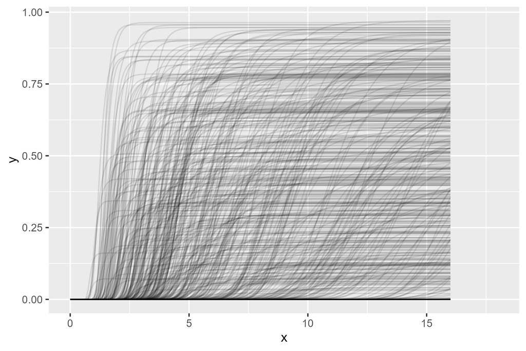

```r
library(tidyverse)

gompertz <- function(xs, asym, b2, b3) {
  asym * exp(-b2 * exp(-b3 * xs))
}

asym <- 1
b2 <- rnorm(50, 5, 2)
b3 <- 1
gompertz_grid <- function(xs, asym, b2, b3, expand = TRUE) {
  if (expand) {
  d <- expand.grid(asym = asym, b2 = b2, b3 = b3) |>
    tibble::rowid_to_column(".draw")
  } else {
    d <- data.frame(asym = asym, b2 = b2, b3 = b3) |>
      tibble::rowid_to_column(".draw")
  }

  expand.grid(.draw = d$.draw, x = xs) |>
    dplyr::left_join(d, by = ".draw", relationship = "many-to-many") |>
    dplyr::mutate(
      y = gompertz(x, asym, b2, b3)
    )
}


xs <- 0:192
x <- (xs / 12)

d <- gompertz_grid(
  x,
  asym = plogis(rnorm(500, 0, 1.5)),
  b2 = rlnorm(500, 8, 1),
  b3 = rgamma(500, 2, 1),
  expand = FALSE
)

d_draw <- d |>
  distinct(.draw, asym, b2, b3) |>
  mutate(
    steepest_growth = log(b2) / b3,
    `log(b2)` = log(b2)
  ) |>
  select(-b2) |>
  tidyr::pivot_longer(-.draw)

library(patchwork)
ggplot(d) +
  aes(x = x, y = y) +
  geom_line(aes(group = .draw), alpha = .1) +
  xlim(0, 18)
```

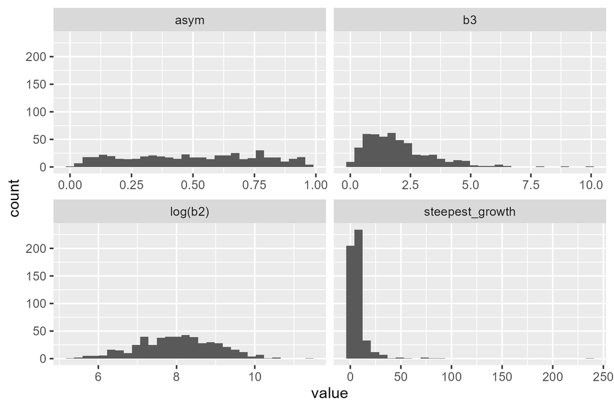

```r
ggplot(d_draw) +
  aes(x = value) +
  geom_histogram() +
  facet_wrap("name", scales = "free_x")
```

b2 and b3 jointly determine the age of steepest growth, so I can’t put a simple prior on it.

**Postscript from 2024.** I never did use this function to model intelligibility.

## December 2022

Source: `2022-12-01.Rmd`

### duckdb

duckdb is awesome. I used it in a project to read in all of control files (tsv files) in a folder into a database with the following code. There is a lot to unpack here, but here are the main ideas:

- dplyr is used to generate the queries that sent to the database.
- The functions that start with `regexp_` are duckdb functions, not R functions, but that’s not a problem because the code that will be run is SQL code in the database.
- Normally, `tbl()` is used to specify a table in a database, but here, the database table is constructed from the tsv files using `read_csv_auto()` with wildcard characters.
- The code in `run_control_file_query()` produces a SQL query. The line with `compute()` is the one that actually has the database execute the query and store the results in a database table.

```r
library(DBI)
library(dplyr)
con <- dbConnect(duckdb::duckdb(dbdir = "data-raw/data.duckdb"))

# Generates a SQL query from all the control files in the
# working directory
run_control_file_query <- function() {
  tbl(con, "read_csv_auto('*Control*File-*.txt', FILENAME = TRUE)") |>
    # this all gets converted to SQL statements that will be executed by the
    # database, so there is a mix of R functions and duckdb functions here.
    select(
      control_file = filename,
      repeat_no = Repeat,
      sentence = Sentence,
      response = Response,
      s_word = SWord,
      m_word = MWord,
      m_word_a = MWordA,
      phonetic_sentence = `Phonetic Sentence`,
      phonetic_response = `Phonetic Response`,
      audio_file = File,
    ) |>
    mutate(
      control_file_number = control_file |>
        regexp_extract('\\d{7}\\d+'),
      item = audio_file |>
        toupper() |>
        # fix files with a subscript letter (S7T10a)
        regexp_replace("[ABCDE].WAV", ".WAV") |>
        # fix files with an extra 0(WT010)
        regexp_replace("0(\\d\\d).WAV", "\\1.WAV") |>
        regexp_extract('(S|S\\d|W)(T)\\d\\d.WAV') |>
        left(-4L),
      tocs_type = ifelse(
        substr(item, 1L, 1L) == "W",
        "single-word",
        "multiword"
      )
    )
}

# Create a table from the first batch of files
withr::with_dir("../files-to-import/2022-10-27-batch-1/", {
  DBI::dbRemoveTable(con, "control_files")
  run_control_file_query() |>
    compute(name = "control_files", temporary = FALSE)
})
```

## September 2022

### The BIC

I was wondering about the so-called Bayesian information criterion (BIC) today. What’s the deal with it? Both the AIC and BIC have the form:

$$\text{penalty}\times k\
\text{parameters} - 2\times \text{model log-likelihood}$$

For the AIC, the penalty is 2, and for the BIC, the penalty is $\ln(n\ \text{observations})$. If we note that `ln(20)` = 2.996 (the penalty for 20 observations), then the BIC penalty is always larger than the AIC penalty in practice.

[See](https://www.jstor.org/stable/43495189) Aho, Derryberry, & Peterson (2014): The AIC prioritizes out-of-sample prediction (asymptotic efficiency). BIC is an approximation of a Bayesian hypothesis test (so, asymptotic consistency). They note that the BIC is ideal when “(1) only a few potential hypotheses are considered and (2) one of the hypotheses is (essentially) correct,” and the AIC worldview is for when there are “(1) numerous hypotheses and (2) the conviction that all of them are to differing degrees wrong.”

## June 2022

Source: `2022-06-06.Rmd`

### Getting [downlit](https://downlit.r-lib.org/index.html) to work on this notebook

notestar, which I use to create this notebook, produces an HTML file. I can then post-process this HTML file using `downlit::downlit_html_path()` so that R function calls are automatically linked to documentation pages. This feature is great, but out of the box, it ignores the syntax highlighting of the output document. The solution, it turns out, is buried in `?rmarkdown::html_document` (look at how nicely that is autolinked). I make sure that the following css file is included in the build process, so that links are underlined and the style defers to the default syntax highlighting coloring.

```css
code a:any-link {
 color: inherit; /* use colour from syntax highlighting */
 text-decoration: underline;
 text-decoration-color: #ccc;
}
```

### Windows Terminal settings for Miniconda

Here is how to add the Miniconda prompt to Windows Terminal. Analogous steps probably will work for an Anaconda prompt.

First, we need to know where the Miniconda prompt lives.

- Find the desired Anaconda/Miniconda prompt in the Start Menu. Right click > Open file location
- Select the shortcut for the Anaconda/Miniconda prompt. Right click > Properties.

Look at the target field. For my Miniconda shortcut, I have:

```
%windir%\System32\cmd.exe "/K" C:\Users\trist\miniconda3\Scripts\activate.bat C:\Users\trist\miniconda3
```

We don’t need to hardcode in my user profile path. I also don’t think that last path is necessary, so this can simplify to:

```
%windir%\System32\cmd.exe /K %USERPROFILE%\miniconda3\Scripts\activate.bat
```

In Windows Terminal, create a terminal profile:

- open Settings > Add a new profile > New empty profile.

#### Interactive setup

We can use the Windows Terminal app to set up the miniconda prompt. Things to change include:

- Name
- Command line: Use the target field from above. In my case, I paste in `%windir%\System32\cmd.exe /K %USERPROFILE%\miniconda3\Scripts\activate.bat`
- Starting directory: I select “Use parent process directory”.
- Icon: I use the snake emoji 🐍 but [this page](https://dev.to/azure/easily-add-anaconda-prompt-in-windows-terminal-to-make-life-better-3p6j) has a hint about using a .ico file.

#### JSON

Instead of the interactive setup, we can open the JSON settings file (Settings > Open JSON file) and modify/paste in the settings. Here are my settings. Here the `guid` field was created by Windows Terminal so we should use the one it provides for us.

```json
{
  "commandline": "%windir%\\System32\\cmd.exe /K %USERPROFILE%\\miniconda3\\Scripts\\activate.bat",
  "guid": "{2679ff34-f6b9-5fcd-9b81-08b50df61bae}",
  "icon": "\ud83d\udc0d",
  "name": "Miniconda",
  "startingDirectory": null
}
```

## April, May 2022

Source: `2022-04-02.Rmd`

### .Rprofile contents

I am now adding the following to my .Rprofile file. By default, `renv::restore()` will undo the entire restore attempt if any of the package installs fails. (It wants the the whole *transaction* to succeed.) The undoes the default so that successful package installs are kept.

```r
options(renv.config.install.transactional = FALSE)
```

My full .Rprofile tends to be something like:

```r
source("renv/activate.R")
options(
  repos = c(
    tjmahr = 'https://tjmahr.r-universe.dev',
    # stan = "https://mc-stan.org/r-packages/",
    getOption("repos")
  )
)
options(WrapRmd.width = 72)
options(styler.addins_style_transformer = "grkstyle::grk_style_transformer()")
options(renv.config.install.transactional = FALSE)
```

Note that I put the renv activation first because it does some work with the repos option and I don’t want to get in the way of it.

### R 4.2.0 alpha notes

These are some notes about workarounds etc. for the devel/alpha version of R 4.2.0 that I have been using on Windows for the past few weeks.

- to fix the text shadow in the syntax highlighting in the docs in RStudio, one workaround is to replace the prism.css file in the folder `C:\Program Files\R\R-4.2.0alpha\doc\html` with a modified css file. I just download the Tomorrow Night theme from https://prismjs.com/ and use that one because it doesn’t have a shadow by default.
- for a clean break, I removed Rtools40 and remove any use of it in the PATH. Rtools42/R 4.2.0 do not depend on the path.
- Rtools42 adds Rtools42 Bash to the start menu. I used `pacman -Syuu` to update the Msys2 stuff in Rtools. If I run this again, it will update other packages.
- Here is the documentation page for Rtools42 https://cran.r-project.org/bin/windows/base/howto-R-4.2.html

## February 2022

Source: `2022-02-01.Rmd`

- [matrixcalculus.org](http://www.matrixcalculus.org/matrixCalculus)

### Phonotactic probability

I asked the PhonCorps Slack what the state of the art was for computing phonotactic probability. I said I was using the [IPhod](https://www.iphod.com/) database with [SUBTLEXus](https://www.ugent.be/pp/experimentele-psychologie/en/research/documents/subtlexus) frequencies. Some response:

- It’s not too hard to compute probabilities by hand if you have a pronunciation dictionary.
- [KU Phonotactic Probability Calculator](https://calculator.ku.edu/phonotactic/about).
  - One person advised that the KU uses the Webster Pocket Dictionary which makes it a subset of the corpus used by IPhod.
- For neighborhood density, [CLEARPOND](https://clearpond.northwestern.edu/) and the [English Lexicon Project](https://elexicon.wustl.edu/) were mentioned.

### R code to parse the KU phonotactic probability calculator output

```r
# Parse the output of https://calculator.ku.edu/phonotactic/about
# in base R

# TJ Mahr

test_lines <- c(
  "b@d - English", "0.0512 0.0794 0.0380", "0.0059 0.0024", "1.1686 1.0083",
  "bcl - English", "0.0512 0.0165 0.0737", "0.0008 0.0035", "1.1414 1.0043",
  "bi - English", "0.0512 0.0318", "0.0022", "1.0830 1.0022",
  "bIg - English", "0.0512 0.0962 0.0179", "0.0041 0.0035", "1.1653 1.0076",
  "but - English", "0.0512 0.0221 0.0660", "0.0012 0.0027", "1.1393 1.0039",
  "bW - English", "0.0512 0.0097", "0.0006", "1.0609 1.0006",
  "bO - English", "0.0512 0.0034", "0.0003", "1.0546 1.0003",
  "b^di - English",
  "0.0512 0.0392 0.0380 0.0432",
  "0.0034 0.0010 0.0037",
  "1.1716 1.0081",
  "b^s - English", "0.0512 0.0392 0.0788", "0.0034 0.0039", "1.1692 1.0073",
  "Cu - English", "0.0089 0.0221", "0.0002", "1.0310 1.0002"
  )

split_ku_chunks <- function(lines) {
  starts <- grep(" - ", lines)
  ends <- c(starts[-1] - 1, length(lines))
  Map(seq, starts, ends) |>
    lapply(function(i) lines[i])
}

parse_ku_chunk <- function(lines) {
  # How the output is documented in the paper.

  # Vitevitch, M.S. & Luce, P.A. (2004) A web-based interface to calculate
  # phonotactic probability for words and nonwords in English. Behavior Research
  # Methods, Instruments, and Computers, 36, 481-487.

  # "The output of the Phonotactic Probability Calculator
  # (which appears in the field on the right side of your
  # browser) typically consists of four lines of information
  # for each item entered in the left field. The first line con-
  # tains the phonemic transcription you originally entered.
  # The second line contains the position-specific probabil-
  # ity for each segment in the item entered by the user. If the
  # (non)word you entered contains more than seven pho-
  # nemes, the position-specific probabilities for each pho-
  # neme in the item will wrap around to the next line.
  #
  # "The third line (assuming the entry is seven phonemes
  # or less) contains the position-specific biphone probabil-
  # ities for each of the biphones in the word."
  pronunciation <- lines[1] |>
    strsplit(" - ") |>
    unlist() |>
    utils::head(1)

  phones <- pronunciation |>
    strsplit("")  |>
    unlist()

  biphones <- paste0(phones[-length(phones)], phones[-1])

  values <- lines[-1] |>
    paste0(collapse = " ") |>
    strsplit(" ") |>
    unlist() |>
    as.numeric()

  i_position_probs <- seq(1, length(phones))
  i_biphone_probs <- seq(1, length(biphones)) + length(phones)

  positional <- data.frame(
    pronunciation = pronunciation,
    class = "positional_prob",
    token = phones,
    value = values[i_position_probs]
  )

  biphone <- data.frame(
    pronunciation = pronunciation,
    class = "biphone_prob",
    token = biphones,
    value = values[i_biphone_probs]
  )

  rbind(positional, biphone)
}

do_call_rbind <- function(xs, ...) do.call(rbind, xs, ...)

test_lines |>
  split_ku_chunks() |>
  lapply(parse_ku_chunk) |>
  do_call_rbind()
```

```
#>    pronunciation           class token  value
#> 1            b@d positional_prob     b 0.0512
#> 2            b@d positional_prob     @ 0.0794
#> 3            b@d positional_prob     d 0.0380
#> 4            b@d    biphone_prob    b@ 0.0059
#> 5            b@d    biphone_prob    @d 0.0024
#> 6            bcl positional_prob     b 0.0512
#> 7            bcl positional_prob     c 0.0165
#> 8            bcl positional_prob     l 0.0737
#> 9            bcl    biphone_prob    bc 0.0008
#> 10           bcl    biphone_prob    cl 0.0035
#> 11            bi positional_prob     b 0.0512
#> 12            bi positional_prob     i 0.0318
#> 13            bi    biphone_prob    bi 0.0022
#> 14           bIg positional_prob     b 0.0512
```

[output cut: 30 more lines]

### Some old random walk code

I had some old code that asked what a 12-step random walk looked like if it started at the ceiling and could on go left or stay put on the first move.

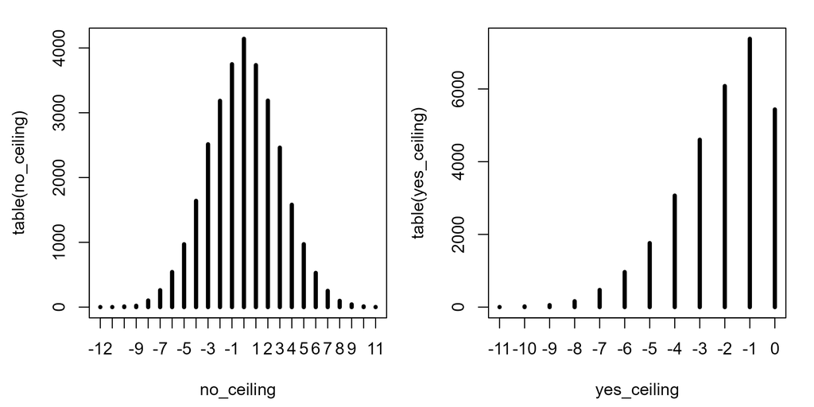

```r
par(mar = c(4, 4, 1, 1))
set.seed(20220209)

take_one_step <- function(x, y, ceiling = 0) {
  this_step <- if (x == ceiling) {
    sample(c(-1, 0), 1)
  } else {
    sample(c(-1, 0, 1), 1)
  }
  x + this_step
}

no_ceiling <- replicate(
  30000,
  Reduce(function(x, y) take_one_step(x, y, ceiling = 1000), 0:12, init = 0)
)

yes_ceiling <- replicate(
  30000,
  Reduce(function(x, y) take_one_step(x, y, ceiling = 0), 0:12, init = 0)
)

library(patchwork)
p1 <- wrap_elements(
  full = ~ plot(table(no_ceiling), lwd = 4)
)
p2 <- wrap_elements(
  full = ~ plot(table(yes_ceiling), lwd = 4)
)

p1 + p2
```

That ain’t a truncated Gaussian. 👀

## January 2022

Source: `2022-01-21.Rmd`

I have decided to get rid of “how to” from heading names. I’m thinking about creating a separate links/bookmarks section.

**New interesting R packages**.

- ggdensity An R package for interpretable visualizations of density estimates https://github.com/jamesotto852/ggdensity
  - the README has a good figure showing a multivariate normal distribution will mess up the density for a bimodal region
- khroma 🎨 Colour Schemes for Scientific Data Visualization https://github.com/tesselle/khroma
- geomtextpath Create curved text paths in ggplot2 https://github.com/AllanCameron/geomtextpath

**Easy way to sample from a multinomial**.

> sample() takes a prob argument, so you can skip rmultinom entirely!  
> sample(n_comp, n, prob = mixture_probs, replace = TRUE)

> — David Robinson ((**drob?**)) [October 27, 2021](https://twitter.com/drob/status/1453453742343442437?ref_src=twsrc%5Etfw)

**Conditionally provide tibbles**. The [newsletter by rOpenSci](https://ropensci.org/blog/2022/01/21/ropensci-news-digest-january-2022/#to-quote-or-not-to-quote-non-existing-words-in-description) highlights this trick by the palmerpenguins package.

```r
delayedAssign("penguins", {
  if (requireNamespace("tibble", quietly = TRUE)) {
    tibble::as_tibble(readRDS("data/penguins.rds"))
  } else {
    readRDS("data/penguins.rds")
  }
})

delayedAssign("penguins_raw", {
  if (requireNamespace("tibble", quietly = TRUE)) {
    tibble::as_tibble(readRDS("data/penguins_raw.rds"))
  } else {
    readRDS("data/penguins_raw.rds")
  }
})
```

This rOpenSci newsletter also detailed how to get new words past the package description spellchecker.